# Importing the libraries

```python
## Ignore warnings

import warnings
warnings.filterwarnings('ignore')

## Pandas and Numpy

import numpy as np
import pandas as pd

## Plotting libraries

import matplotlib.pyplot as plt
import seaborn as sns

## Stats libraries

from scipy.stats import zscore
import statsmodels.api as sm
from statsmodels.formula.api import ols

## Machine Learning Libraries

from sklearn.model_selection import train_test_split
from sklearn.preprocessing import StandardScaler
from sklearn.linear_model import LogisticRegression
from sklearn.svm import SVC
from sklearn.neighbors import KNeighborsClassifier
from sklearn.naive_bayes import GaussianNB
from xgboost import XGBClassifier
from sklearn.ensemble import RandomForestClassifier
from sklearn.metrics import confusion_matrix, accuracy_score, classification_report
from sklearn.model_selection import RandomizedSearchCV, GridSearchCV
from sklearn.model_selection import KFold, StratifiedKFold, ShuffleSplit, LeavePOut, LeaveOneOut
from sklearn.model_selection import cross_val_score

## Library for upsampling

from imblearn.over_sampling import SMOTE
```

# Importing the dataset

```python
## Reading the two datasets

df = pd.read_csv('signal-data.csv')

## Shape of dataset

df.shape
```

```
(1567, 592)
```

# Data Cleansing

```python
## Removing the time stamp as it may not be required in the analysis

df = df.iloc[:,1:]
```

```python
## Checking and removing columns columns with more than 2% missing values (more than 31 missing values)

column_wise_na = df.isna().sum()
lst1 = column_wise_na[column_wise_na>31].index
df = df.drop(lst1, axis = 1)
```

```python
## Dropping the rows with remaining NA values

df = df.dropna()
```

```python
## Dropping columns with no variance (constant values)

lst2 = df.std()[df.std()==0].index
df = df.drop(lst2, axis = 1)
```

```python
## Dropping columns with very low coefficient of variation (using absolute coeff of variation or also known as relative std dev)

acv = df.std()/abs(df.mean())
lst3 = acv[acv<0.01].index
df = df.drop(lst3, axis = 1)
```

```python
df
```

|  | 0 | 1 | 2 | 3 | 4 | 6 | 7 | 8 | 9 | 10 | ... | 576 | 577 | 583 | 584 | 585 | 586 | 587 | 588 | 589 | Pass/Fail |
| --- | --- | --- | --- | --- | --- | --- | --- | --- | --- | --- | --- | --- | --- | --- | --- | --- | --- | --- | --- | --- | --- |
| 1 | 3095.78 | 2465.14 | 2230.4222 | 1463.6606 | 0.8294 | 102.3433 | 0.1247 | 1.4966 | -0.0005 | -0.0148 | ... | 1.1065 | 10.9003 | 0.0223 | 0.0055 | 4.4447 | 0.0096 | 0.0201 | 0.0060 | 208.2045 | -1 |
| 2 | 2932.61 | 2559.94 | 2186.4111 | 1698.0172 | 1.5102 | 95.4878 | 0.1241 | 1.4436 | 0.0041 | 0.0013 | ... | 2.0952 | 9.2721 | 0.0157 | 0.0039 | 3.1745 | 0.0584 | 0.0484 | 0.0148 | 82.8602 | 1 |
| 3 | 2988.72 | 2479.90 | 2199.0333 | 909.7926 | 1.3204 | 104.2367 | 0.1217 | 1.4882 | -0.0124 | -0.0033 | ... | 1.7585 | 8.5831 | 0.0103 | 0.0025 | 2.0544 | 0.0202 | 0.0149 | 0.0044 | 73.8432 | -1 |
| 4 | 3032.24 | 2502.87 | 2233.3667 | 1326.5200 | 1.5334 | 100.3967 | 0.1235 | 1.5031 | -0.0031 | -0.0072 | ... | 1.6597 | 10.9698 | 0.4766 | 0.1045 | 99.3032 | 0.0202 | 0.0149 | 0.0044 | 73.8432 | -1 |
| 5 | 2946.25 | 2432.84 | 2233.3667 | 1326.5200 | 1.5334 | 100.3967 | 0.1235 | 1.5287 | 0.0167 | 0.0055 | ... | 1.6679 | 13.7755 | 0.0189 | 0.0044 | 3.8276 | 0.0342 | 0.0151 | 0.0052 | 44.0077 | -1 |
| ... | ... | ... | ... | ... | ... | ... | ... | ... | ... | ... | ... | ... | ... | ... | ... | ... | ... | ... | ... | ... | ... |
| 1538 | 3128.11 | 2367.16 | 2223.5333 | 1352.1869 | 0.8714 | 97.2189 | 0.1196 | 1.3907 | 0.0074 | 0.0078 | ... | 1.2878 | 22.9183 | 0.0144 | 0.0037 | 2.9002 | 0.0237 | 0.0112 | 0.0038 | 47.3376 | -1 |
| 1539 | 2908.94 | 2560.99 | 2187.3444 | 2882.8558 | 1.5876 | 85.4189 | 0.1235 | 1.4167 | 0.0041 | -0.0056 | ... | 77.5303 | 67.4386 | 0.0118 | 0.0028 | 2.3583 | 0.0237 | 0.0112 | 0.0038 | 47.3376 | -1 |
| 1540 | 2996.04 | 2555.92 | 2190.7666 | 3530.2362 | 0.8017 | 83.8767 | 0.1249 | 1.4158 | -0.0029 | 0.0000 | ... | 1.9501 | 25.2760 | 0.0163 | 0.0035 | 3.2608 | 0.0181 | 0.0123 | 0.0046 | 67.6676 | -1 |
| 1541 | 3246.31 | 2499.79 | 2216.8111 | 1190.4067 | 2.5148 | 114.5533 | 0.1230 | 1.3966 | -0.0057 | -0.0169 | ... | 1.5487 | 11.8247 | 0.0103 | 0.0030 | 2.0418 | 0.0266 | 0.0063 | 0.0019 | 23.5979 | -1 |
| 1550 | 3072.20 | 2406.47 | 2195.4444 | 2914.1792 | 1.5978 | 85.1011 | 0.1235 | 1.3148 | -0.0024 | 0.0039 | ... | 1.3361 | 21.7713 | 0.0178 | 0.0043 | 3.5459 | 0.0236 | 0.0065 | 0.0022 | 27.5514 | -1 |

1436 rows × 402 columns

```python
## Renaming the Pass/Fail Column to Pass and changing the -1 and 1 tags to Yes and No

df.rename(columns = {'Pass/Fail':'Pass'}, inplace = True)
```

```python
## Renaming the categories for Pass and Fail

df.Pass.replace({-1:'Pass', 1:'Fail'}, inplace = True)
```

```python
## Changing column names for ease of calculations

Columns = df.columns
Columns[:-1]

cols = []
for i in Columns[:-1]:
    a = 'Col_'+i
    cols.append(a)

cols.append('Pass')
df.columns = cols
```

```python
## Removing columns using results from ANOVA.
## The null hypothesis being the mean value of the attribute in a given column is the same for Pass and Fail cases.
## When p value is less than 0.01 we reject the null hypothesis and therefore keep those columns while dropping the others

cols4removal = []
for i in df.columns[:-1]:
    a = i + " ~ Pass"
    mod = ols(a, data = df).fit()
    aov_table = sm.stats.anova_lm(mod, typ = 2)
    if aov_table['PR(>F)'][0] > 0.01:
        cols4removal.append(i)

df = df.drop(cols4removal, axis = 1)
```

```python
## Checking the shape of the remaining data

df.shape
```

```
(1436, 40)
```

```python
## Scaling the data for easier visualization (mainly in boxplots)

dfscaled = df.iloc[:,:-1].apply(zscore)
dfscaled['Pass'] = df['Pass']
```

# Data Analysis and Visualization

### Checking distribution with histograms

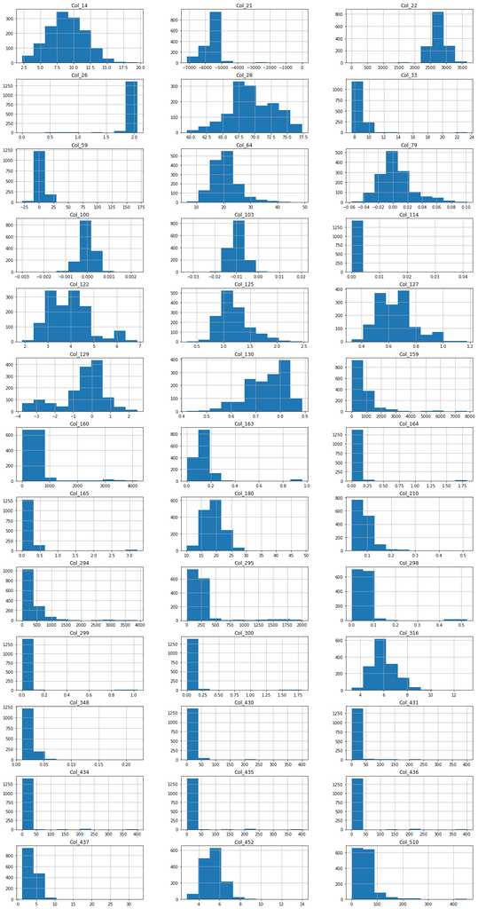

```python
df.hist(layout= (13,3), figsize=(20,40));
```

##### We see that while some of the variables(sensors) have normal distribution others mostly operate in the same range except for a few outliers.

##### It would be interesting to see if some of these outliers are actually situations where we see failure

### Checking distribution with boxplot and checking if distribution is different for Pass and Fail

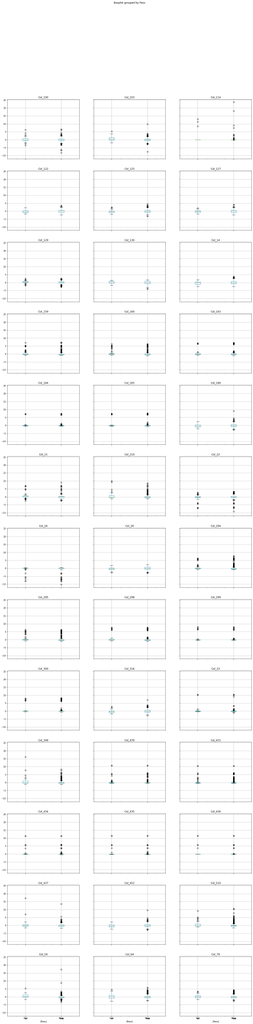

```python
dfscaled.boxplot(by='Pass', layout= (13,3), figsize=(20,80));
```

### Checking Correlations among the X variables

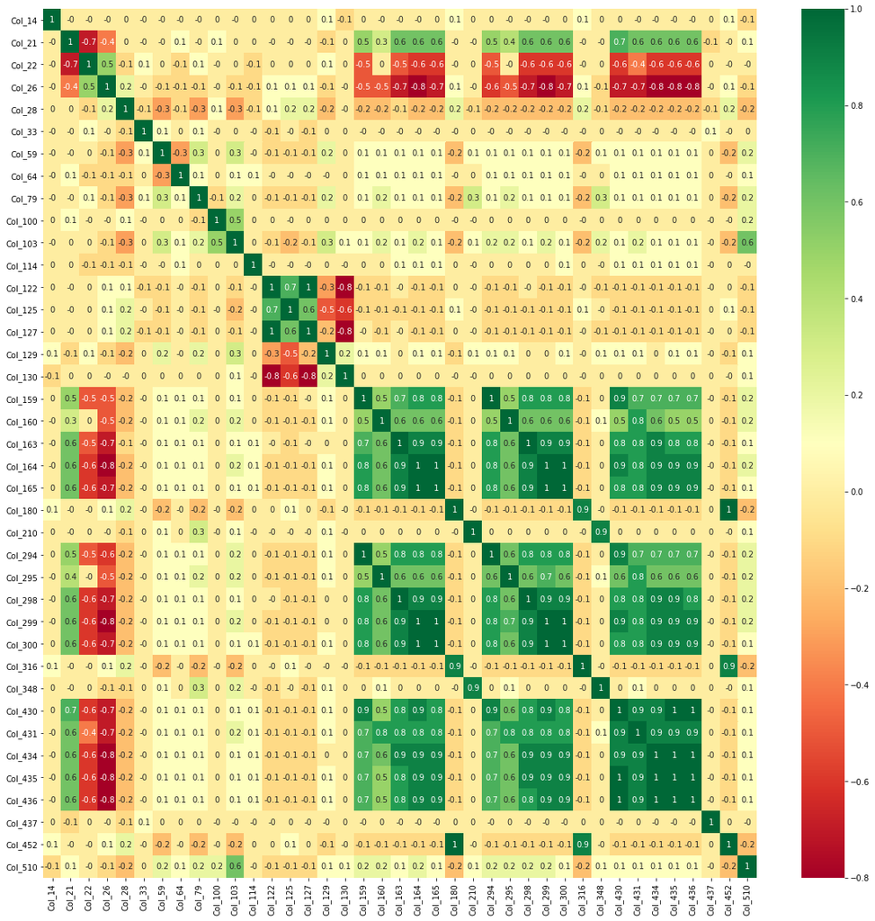

```python
## Corrplot or Correlogram

plt.subplots(figsize=(20,20))
sns.heatmap(round(df.corr(),1), annot=True, cmap = 'RdYlGn' )

plt.show()
```

### Creating pairplots for variables where we see some relationships

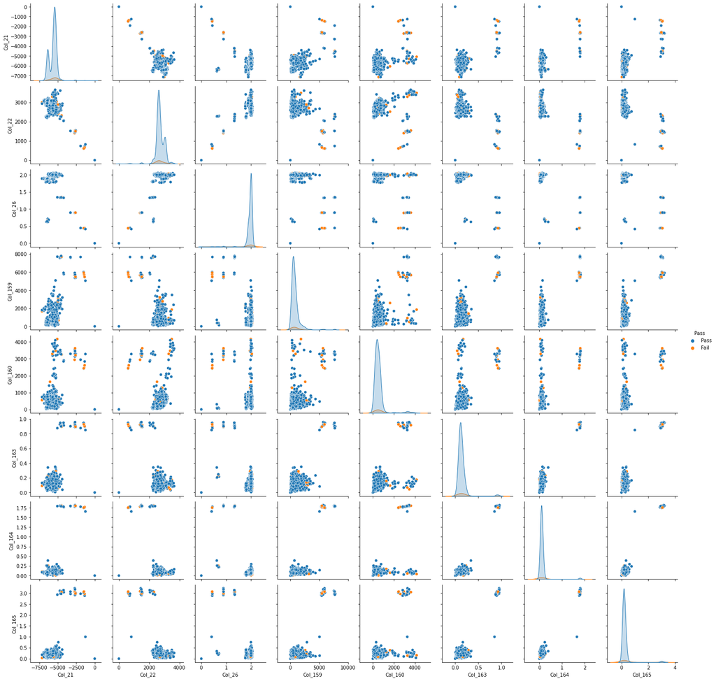

```python
## Columns 21, 22, 26, 159, 160, 163, 164, 165,

df2 = df.iloc[:,1:4].merge(df.iloc[:,17:22], right_index = True, left_index = True)
df2 = df2.merge(df.iloc[:,39],right_index = True, left_index = True)
sns.pairplot(df2, diag_kind='kde', hue = 'Pass');
```

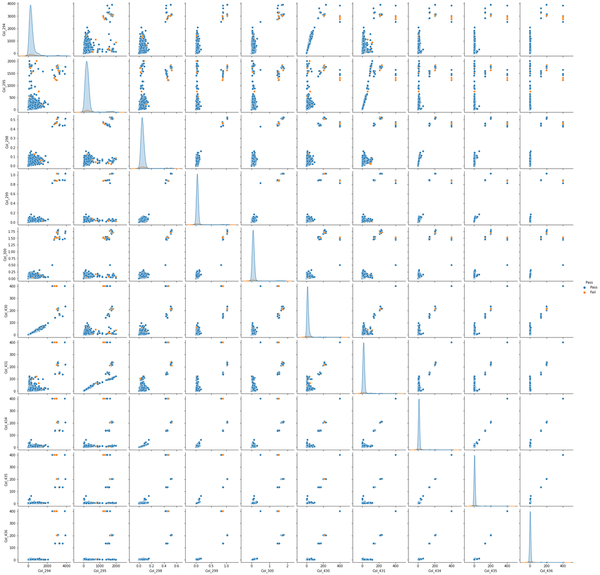

```python
## Columns 294, 295, 298, 299, 300, 430, 431, 434, 435, 436

df2 = df.iloc[:,24:29].merge(df.iloc[:,31:36],right_index = True, left_index = True)
df2 = df2.merge(df.iloc[:,39],right_index = True, left_index = True)
sns.pairplot(df2, diag_kind='kde', hue = 'Pass');
```

##### We see that a lot of the Fail cases are away from the main distribution. They may be the outliers observed in the histograms earlier

# Data Preprocessing

```python
## Seperating X variables and Y variables

X = df.iloc[:,:-1]
y = df.iloc[:,-1]
```

```python
## Checking for target balancing

y.value_counts()
```

```
Pass    1336
Fail     100
Name: Pass, dtype: int64
```

##### Since the dataset has imbalanced classes we need to oversample for the under-represented class

```python
## Using SMOTE to oversample the Fail class

smote = SMOTE()

X_new, y_new = smote.fit_resample(X,y)

print(y.value_counts(),'\n')
print(y_new.value_counts())
```

```
Pass    1336
Fail     100
Name: Pass, dtype: int64

Fail    1336
Pass    1336
Name: Pass, dtype: int64
```

##### Target variable now has balanced classes

```python
## Performing Train-Test split

X_train, X_test, y_train, y_test = train_test_split(X_new, y_new, test_size=0.25, random_state=42)
```

```python
## Standardizing data using standarscalar

sc = StandardScaler()
sc.fit(X_train)
X_train = sc.transform(X_train)
X_test = sc.transform(X_test)
```

##### Checking if the test data has same shape and statistical characterstics after train test split

```python
X_train.shape
```

```
(2004, 39)
```

```python
X_test.shape
```

```
(668, 39)
```

```python
y_train.shape
```

```
(2004,)
```

```python
y_test.shape
```

```
(668,)
```

```python
y_test.value_counts()
```

```
Pass    336
Fail    332
Name: Pass, dtype: int64
```

##### We see that the y_test data set has balanced classes.

# Model Training, Testing and Tuning

```python
## Trying a Logistic Regression model with K-fold, Shuffle Split, Stratified K fold and Leave one out cross validation techniques

kfold = KFold(n_splits = 10)
ss = ShuffleSplit(n_splits=10, test_size=0.25, random_state= 42)
skf = StratifiedKFold(n_splits=10)
loo = LeaveOneOut()

model = LogisticRegression()


results= cross_val_score(estimator=model, X = X_train, y= y_train, cv = kfold)
print(f"Mean Accuracy on validation KFold :{round(results.mean()*100.0,2)}% and Standard Devation of accuracy {round(results.std()*100.0,2)}%")


results= cross_val_score(estimator=model, X = X_train, y= y_train, cv = ss)
print(f"Mean Accuracy on validation Shuffle Split :{round(results.mean()*100.0,2)}% and Standard Devation of accuracy {round(results.std()*100.0,2)}%")


results = cross_val_score(estimator=model, X = X_train, y= y_train, cv = skf)
print(f"Mean Accuracy on validation Stratified KFold :{round(results.mean()*100.0,2)}% and Standard Devation of accuracy {round(results.std()*100.0,2)}%")


results = cross_val_score(estimator=model, X = X_train, y= y_train, cv = loo)
print(f"Mean Accuracy on validation Leave one out:{round(results.mean()*100.0,2)}% and Standard Devation of accuracy {round(results.std()*100.0,2)}%")


model.fit(X_train,y_train)
print(f'Accuracy of Model on test score is {round(100*model.score(X_test,y_test),2)}%','\n')
```

```
Mean Accuracy on validation KFold :77.89% and Standard Devation of accuracy 1.88%
Mean Accuracy on validation Shuffle Split :76.89% and Standard Devation of accuracy 1.1%
Mean Accuracy on validation Stratified KFold :78.04% and Standard Devation of accuracy 2.84%
Mean Accuracy on validation Leave one out:77.94% and Standard Devation of accuracy 41.46%
Accuracy of Model on test score is 78.44%
```

```python
print(classification_report(y_test,model.predict(X_test)))
```

```
              precision    recall  f1-score   support

        Fail       0.79      0.78      0.78       332
        Pass       0.78      0.79      0.79       336

    accuracy                           0.78       668
   macro avg       0.78      0.78      0.78       668
weighted avg       0.78      0.78      0.78       668
```

```python
print(confusion_matrix(y_test,model.predict(X_test)))
```

```
[[258  74]
 [ 70 266]]
```

```python
## Trying with PCA
from sklearn.decomposition import PCA
Xscaled = X.apply(zscore)
covMatrix = np.cov(Xscaled,rowvar = False)
pca = PCA(n_components=25)
pca.fit(Xscaled)
print(pca.explained_variance_)
print(pca.explained_variance_ratio_)
```

```
[13.88824937  3.86461677  3.04679829  2.23271712  1.70585294  1.63419088
  1.29417334  1.21836249  1.05759419  1.03234484  0.99817066  0.9067499
  0.82389547  0.74568403  0.67456474  0.61836902  0.58429324  0.50441754
  0.44607553  0.32073594  0.28150371  0.26386836  0.22403081  0.19920655
  0.16773561]
[0.35586097 0.09902373 0.07806863 0.05720929 0.04370936 0.04187315
 0.03316082 0.03121831 0.02709892 0.02645195 0.0255763  0.02323381
 0.02111081 0.01910679 0.01728449 0.01584457 0.01497144 0.01292478
 0.01142987 0.00821827 0.00721302 0.00676114 0.00574038 0.0051043
 0.00429792]
```

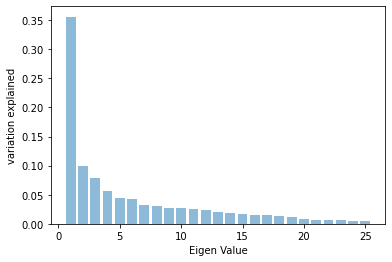

```python
plt.bar(list(range(1,26)), pca.explained_variance_ratio_, alpha = 0.5, align = 'center')
plt.ylabel('variation explained')
plt.xlabel('Eigen Value')
plt.show()
```

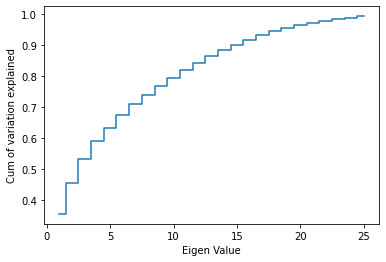

```python
plt.step(list(range(1,26)), np.cumsum(pca.explained_variance_ratio_), where = 'mid')
plt.ylabel('Cum of variation explained')
plt.xlabel('Eigen Value')
plt.show()
```

```python
np.round(np.cumsum(pca.explained_variance_ratio_),3)
```

```
array([0.356, 0.455, 0.533, 0.59 , 0.634, 0.676, 0.709, 0.74 , 0.767,
       0.794, 0.819, 0.842, 0.864, 0.883, 0.9  , 0.916, 0.931, 0.944,
       0.955, 0.963, 0.971, 0.977, 0.983, 0.988, 0.992])
```

```python
Xpca_train = pca.transform(X_train)
Xpca_test = pca.transform(X_test)
model_pca = LogisticRegression()
model_pca.fit(Xpca_train,y_train)
print(f'Test Accuracy of Logistic Regression model after doing PCA is {round(100*model_pca.score(Xpca_test,y_test),2)}%')
```

```
Test Accuracy of Logistic Regression model after doing PCA is 78.59%
```

##### Since Model results do not get significantly better with PCA moreover we did not see any overfitting when testing with all 40 variables we decide not to do pca in the other models.

##### Point to note the variable universe has already by significantly reduced using various methods including removing constants, missing values>threshold and Anova. Therefore there isn't a big need to do PCA

```python
X_train, X_test, y_train, y_test = train_test_split(X_new, y_new, test_size=0.2, random_state=42)
```

#### Logistic Regression

```python
from sklearn.pipeline import Pipeline

pipe_logistic = Pipeline([('scl',StandardScaler()),('LR' , LogisticRegression())])

# Create param grid.

param_grid_logistic = {  'LR__penalty' : ['l1', 'l2'],
                         'LR__C' : np.logspace(-4, 4, 20),
                         'LR__solver' : ['liblinear']}

# Create grid search object

clf_lr = GridSearchCV(pipe_logistic, param_grid = param_grid_logistic, cv = 5, verbose=3, n_jobs=-1)

# Fit on data

best_clf_lr = clf_lr.fit(X_train, y_train)
```

```
Fitting 5 folds for each of 40 candidates, totalling 200 fits
```

```python
print(" Best cross-validation accuracy: {:.2f}". format( clf_lr.best_score_))
print(" Best parameters: ", clf_lr.best_params_)
print(" Test set accuracy: {:.2f}". format( clf_lr.score( X_test, y_test)))
```

```
 Best cross-validation accuracy: 0.78
 Best parameters:  {'LR__C': 1.623776739188721, 'LR__penalty': 'l1', 'LR__solver': 'liblinear'}
 Test set accuracy: 0.78
```

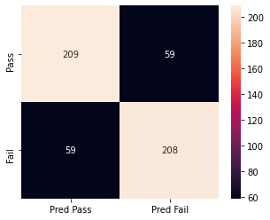

```python
## Drawing up the confusion matrix for the best Logistic Regression Model

lab = ['Pass', 'Fail']
plab = ['Pred Pass', 'Pred Fail']
cm = confusion_matrix(y_test,clf_lr.predict(X_test),labels = lab)

df_cm = pd.DataFrame(cm, index = [i for i in lab], columns = [i for i in plab])
plt.figure(figsize = (5,4))
sns.heatmap(df_cm ,annot=True, fmt = 'g');
```

```python
## Printing the classification report for the best Logistic Regression Model

print(classification_report(y_test,clf_lr.predict(X_test)))
```

```
              precision    recall  f1-score   support

        Fail       0.78      0.78      0.78       267
        Pass       0.78      0.78      0.78       268

    accuracy                           0.78       535
   macro avg       0.78      0.78      0.78       535
weighted avg       0.78      0.78      0.78       535
```

The F1 Score for both classes for the best logistic regression is quite low, precision and recall are also low

#### Support Vector Classifier

```python
pipe_svc = Pipeline([('scl',StandardScaler()),('svc' , SVC())])

# Create param grid.

param_grid_svc = { 'svc__C': [0.001, 0.01, 0.1, 1, 10, 100],
                        'svc__gamma': [0.001, 0.01, 0.1, 1, 10],
                        'svc__kernel':['rbf','linear']
                  }



#    {'classifier' : [RandomForestClassifier()],
 #   'classifier__n_estimators' : list(range(100,500,100)),
  #  'classifier__max_features' : list(range(5,20,5))},
   #  #  {'classifier': [GaussianNB()],
  #  }

# Create grid search object

clf_svc = GridSearchCV(pipe_svc, param_grid = param_grid_svc, cv = 5, verbose=3, n_jobs=-1)

# Fit on data

best_clf_svc = clf_svc.fit(X_train, y_train)
```

```
Fitting 5 folds for each of 60 candidates, totalling 300 fits
```

```python
print(" Best cross-validation accuracy: {:.2f}". format( clf_svc.best_score_))
print(" Best parameters: ", clf_svc.best_params_)
print(" Test set accuracy: {:.2f}". format( clf_svc.score( X_test, y_test)))
```

```
 Best cross-validation accuracy: 0.97
 Best parameters:  {'svc__C': 10, 'svc__gamma': 0.1, 'svc__kernel': 'rbf'}
 Test set accuracy: 0.97
```

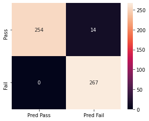

```python
## Drawing up the confusion matrix for the best SVC Model

lab = ['Pass', 'Fail']
plab = ['Pred Pass', 'Pred Fail']
cm = confusion_matrix(y_test,clf_svc.predict(X_test),labels = lab)

df_cm = pd.DataFrame(cm, index = [i for i in lab], columns = [i for i in plab])
plt.figure(figsize = (5,4))
sns.heatmap(df_cm ,annot=True, fmt = 'g');
```

```python
## Printing the classification report for the best Support Vector Classifier

print(classification_report(y_test,clf_svc.predict(X_test)))
```

```
              precision    recall  f1-score   support

        Fail       0.95      1.00      0.97       267
        Pass       1.00      0.95      0.97       268

    accuracy                           0.97       535
   macro avg       0.98      0.97      0.97       535
weighted avg       0.98      0.97      0.97       535
```

The F1 Score for both classes for the best SVC is quite good, precision and recall are also good

#### Random Forest Classifier

```python
pipe_rf = Pipeline([('scl',StandardScaler()),('rf' , RandomForestClassifier())])

# Create param grid.

param_grid_rf = { 'rf__n_estimators'     : [100,200,300,400,500],
                  'rf__max_features'     : ['auto', 'sqrt'],
                  'rf__max_depth'        : [10,20,30,40,50],
                  'rf__min_samples_split': [2, 5, 10],
                  'rf__min_samples_leaf' : [1, 2, 4]}

# Create grid search object

clf_rf = GridSearchCV(pipe_rf, param_grid = param_grid_rf, cv = 3, verbose=3, n_jobs=-1)

# Fit on data

best_clf_rf = clf_rf.fit(X_train, y_train)
```

```
Fitting 3 folds for each of 450 candidates, totalling 1350 fits
```

```python
print(" Best cross-validation accuracy: {:.2f}". format( clf_rf.best_score_))
print(" Best parameters: ", clf_rf.best_params_)
print(" Test set accuracy: {:.2f}". format( clf_rf.score( X_test, y_test)))
```

```
 Best cross-validation accuracy: 0.95
 Best parameters:  {'rf__max_depth': 40, 'rf__max_features': 'sqrt', 'rf__min_samples_leaf': 1, 'rf__min_samples_split': 2, 'rf__n_estimators': 500}
 Test set accuracy: 0.96
```

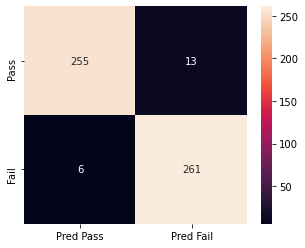

```python
## Drawing up the confusion matrix for the best RF Model

lab = ['Pass', 'Fail']
plab = ['Pred Pass', 'Pred Fail']
cm = confusion_matrix(y_test,clf_rf.predict(X_test),labels = lab)

df_cm = pd.DataFrame(cm, index = [i for i in lab], columns = [i for i in plab])
plt.figure(figsize = (5,4))
sns.heatmap(df_cm ,annot=True, fmt = 'g');
```

```python
## Printing the classification report for the best Support Vector Classifier

print(classification_report(y_test,clf_rf.predict(X_test)))
```

```
              precision    recall  f1-score   support

        Fail       0.95      0.98      0.96       267
        Pass       0.98      0.95      0.96       268

    accuracy                           0.96       535
   macro avg       0.96      0.96      0.96       535
weighted avg       0.96      0.96      0.96       535
```

The accuracy of RF model is slightly worse than the SVC the F1 score is also slightly less than the SVC, precision and recall are also slightly less. RF predicts one Pass case better

#### XGBoost Classifier

```python
pipe_xgb = Pipeline([('scl',StandardScaler()),('xgb' , XGBClassifier())])

# Create param grid.

param_grid_xgb = { "xgb__colsample_bytree" : [round(x,2) for x in np.linspace(.1,1,num=3)],
                   "xgb__gamma"            : [round(x,2) for x in np.linspace(.1,0.5,num=3)],
                   "xgb__learning_rate"    : [0.03, 0.1, 0.3],
                   "xgb__max_depth"        : [3,4,5],
                   "xgb__n_estimators"     : [100,200,300,400,500]}

# Create grid search object

clf_xgb = GridSearchCV(pipe_xgb, param_grid = param_grid_xgb, cv = 3, verbose=3, n_jobs=-1)

# Fit on data

best_clf_xgb = clf_xgb.fit(X_train, y_train)
```

```
Fitting 3 folds for each of 405 candidates, totalling 1215 fits
[21:44:43] WARNING: C:/Users/Administrator/workspace/xgboost-win64_release_1.4.0/src/learner.cc:1095: Starting in XGBoost 1.3.0, the default evaluation metric used with the objective 'binary:logistic' was changed from 'error' to 'logloss'. Explicitly set eval_metric if you'd like to restore the old …
```

```python
print(" Best cross-validation accuracy: {:.2f}". format( clf_xgb.best_score_))
print(" Best parameters: ", clf_xgb.best_params_)
print(" Test set accuracy: {:.2f}". format( clf_xgb.score( X_test, y_test)))
```

```
 Best cross-validation accuracy: 0.96
 Best parameters:  {'xgb__colsample_bytree': 0.55, 'xgb__gamma': 0.1, 'xgb__learning_rate': 0.1, 'xgb__max_depth': 4, 'xgb__n_estimators': 500}
 Test set accuracy: 0.96
```

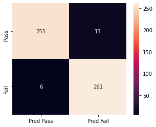

```python
## Drawing up the confusion matrix for the best XGB Model

lab = ['Pass', 'Fail']
plab = ['Pred Pass', 'Pred Fail']
cm = confusion_matrix(y_test,clf_xgb.predict(X_test),labels = lab)

df_cm = pd.DataFrame(cm, index = [i for i in lab], columns = [i for i in plab])
plt.figure(figsize = (5,4))
sns.heatmap(df_cm ,annot=True, fmt = 'g');
```

```python
## Printing the classification report for the best Support Vector Classifier

print(classification_report(y_test,clf_xgb.predict(X_test)))
```

```
              precision    recall  f1-score   support

        Fail       0.95      0.98      0.96       267
        Pass       0.98      0.95      0.96       268

    accuracy                           0.96       535
   macro avg       0.96      0.96      0.96       535
weighted avg       0.96      0.96      0.96       535
```

Although the XGB Model performs slightly worse than the SVC model it has the same results as RF and the F1 score is still very high

#### Comparing all models

```python
## Storing the model artifacts in a dataframe for comparison

comparison_df = pd.DataFrame({'Algorithm':['Logistic Regression', 'Support Vector Classifier', 'Random Forest Classifier','XGBoost Classifier'],
                              'Best Parameters':[clf_lr.best_params_,clf_svc.best_params_,clf_rf.best_params_,clf_xgb.best_params_],
                              'Train (CV) Accuracy':[clf_lr.best_score_,clf_svc.best_score_,clf_rf.best_score_,clf_xgb.best_score_],
                              'Test Accuracy':[clf_lr.score(X_test, y_test),clf_svc.score(X_test, y_test),clf_rf.score(X_test, y_test),clf_xgb.score(X_test, y_test)]
                             })
```

```python
comparison_df
```

|  | Algorithm | Best Parameters | Train (CV) Accuracy | Test Accuracy |
| --- | --- | --- | --- | --- |
| 0 | Logistic Regression | {'LR__C': 1.623776739188721, 'LR__penalty': 'l... | 0.775377 | 0.779439 |
| 1 | Support Vector Classifier | {'svc__C': 10, 'svc__gamma': 0.1, 'svc__kernel... | 0.968171 | 0.973832 |
| 2 | Random Forest Classifier | {'rf__max_depth': 40, 'rf__max_features': 'sqr... | 0.952262 | 0.964486 |
| 3 | XGBoost Classifier | {'xgb__colsample_bytree': 0.55, 'xgb__gamma': ... | 0.955540 | 0.964486 |

### Overall we looked at 4 Classifiers -

1. Logistic Regression (Linear Model)
2. One Support Vector
3. One Bagging Ensemble Model - Random Forest
4. One Boosting Ensemble Model - XGBoost

## Final Model Fitting

```python
pipe_final = Pipeline([('scl',StandardScaler()),('svc' , SVC(C= 10, gamma = 0.1, kernel = 'rbf'))])

pipe_final.fit(X_new, y_new)
```

```
Pipeline(steps=[('scl', StandardScaler()), ('svc', SVC(C=10, gamma=0.1))])
```

```python
## Creating a pickle file

import pickle

pickle.dump(pipe_final, open('final_model.pkl','wb'))
```

## Future Predictions

```python
## Loading the pickle file

model4_FuturePred = pickle.load(open('final_model.pkl','rb'))
```

```python
## Loading the future predictions dataset and removing the extra columns in future prediction data set

df_fp = pd.read_excel('Future_predictions.xlsx')
columns = df_fp.columns

cols = []
for i in columns:
    a = 'Col_'+str(i)
    cols.append(a)

df_fp.columns = cols
df_fp = df_fp.loc[:, df_fp.columns.intersection(['Col_14', 'Col_21', 'Col_22', 'Col_26', 'Col_28', 'Col_33', 'Col_59',
       'Col_64', 'Col_79', 'Col_100', 'Col_103', 'Col_114', 'Col_122',
       'Col_125', 'Col_127', 'Col_129', 'Col_130', 'Col_159', 'Col_160',
       'Col_163', 'Col_164', 'Col_165', 'Col_180', 'Col_210', 'Col_294',
       'Col_295', 'Col_298', 'Col_299', 'Col_300', 'Col_316', 'Col_348',
       'Col_430', 'Col_431', 'Col_434', 'Col_435', 'Col_436', 'Col_437',
       'Col_452', 'Col_510'])]
```

```python
## Predictions using the stored model

model4_FuturePred.predict(df_fp)
```

```
array(['Pass', 'Pass', 'Fail', 'Pass', 'Pass', 'Pass', 'Pass', 'Pass',
       'Pass', 'Pass', 'Fail', 'Fail', 'Pass', 'Pass', 'Fail', 'Pass',
       'Pass', 'Pass'], dtype=object)
```

# Conclusions

The Dataset was huge in terms of the number of features however, using various techniques we can reduce the number of dimensions, While it is tempting to just apply PCA for dimensionality reduction but one can do feature engineering in otherways as well and retain the explainability of the model. Which is what we did in the current problem

While we could use other models as well, I chose to use the different types of classifiers choosing one from each bagging, boosting, SVM, and Logistic Regression I also tried Naive Bayes however, the results were as low as a 57% test accuracy

Overall the SVM model works the best with the least number of classification and hence the final model is made using that. The other models were also close and there is a chance that with a larger parameter grid one of the other models does better.